```r
# Seed for random number generation
set.seed(42)
knitr::opts_chunk$set(cache.extra = knitr::rand_seed)
```

The US sample included 109 participants (27M, 78F, 3 non-binary, 1 other), with mean age = 22.4 (SD = 8.49) and median age = 20. The VN sample included 57 participants (17M, 40F), with mean age = 22.21 (SD = 6.12) and median age = 21. The CN sample included 132 participants (51M, 81F), with mean age = 23.27 (SD = 3.75) and median age = 23.

## Do we extend previous work reporting a preference for taxonomic matching in the US and thematic matching in Asia?

The group means of proportion of thematic response in mainland China is the highest (M = 0.65, SD = 0.12), followed by the groups means in Vietnam (M = 0.6, SD = 0.13), which is slightly higher than that of the US (M = 0.56, SD = 0.17).

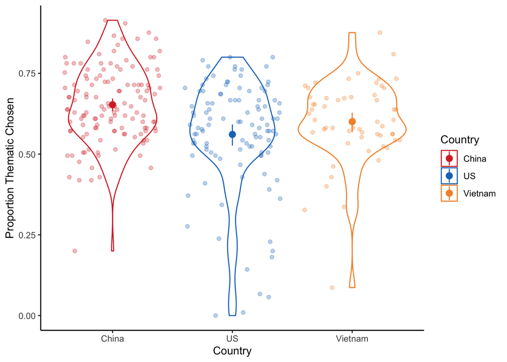

Proportion of thematic responses by country. Only US-China responding comparison shows a siginficant difference. We could not extend this to US-Vietnam responding comparison.

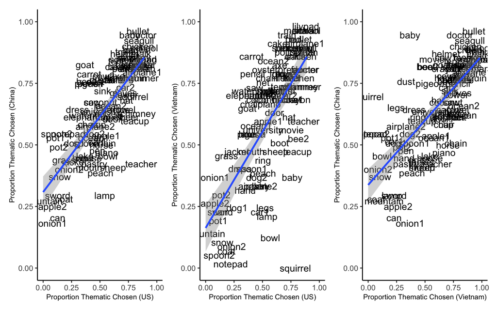

Correlation between proportion thematic chosen by US-China participants, US-Vietnam participants, and China-Vietnam participants. All three comparisons show strong correlation, suggesting a strong signal of universality across cultural contexts regarding similarity judgments

```r
plotUSCN + plotUSVN + plotCNVN +
  plot_layout(ncol = 3)
```

With a Pearson correlation test, we observed high correlations between thematic responding across all three countries. The proportion of US thematic responding is strongly correlated with thematic responding in China, $r = .75$, 95% CI $[.65, .82]$, $t(103) = 11.56$, $p < .001$. The proportion of US thematic responding is strongly correlated with thematic responding in Vietnam, $r = .70$, 95% CI $[.58, .78]$, $t(103) = 9.86$, $p < .001$. Likewise, the proportion of China thematic response is strongly correlated with thematic responding in Vietnam, $r = .72$, 95% CI $[.61, .80]$, $t(103) = 10.55$, $p < .001$. This points to a strong signal of universality across cultural contexts regarding similarity judgments.

For comparison with previous work, we also included an effect size comparison for the difference in US-China thematic response data (though this was not a planned analysis). The effect size for this analysis was d = 0.4380701, a small effect size. This is smaller than the effect size from @Ji2004, even when we are unable to make a direct comparison. Calculating the effect size from the ANOVA reported in @Ji2004 between US participants tested in English and mainland China participants tested in English (both groups tested in the US) yields a Cohen’s d = 0.81. @Ji2004 reported that mean thematic response for mainland China participants tested in Mandarin Chinese is higher than for those tested in English, so the effect size for a comparison between mainland China participants tested in Mandarin Chinese and US participants tested in English (parallel to our comparison) would likely have yielded an even larger effect size than 0.814. It is possible that we failed to replicate the magnitude of effect from @Ji2004 because the previous study calculated their dependent variable as frequency of thematic responses minus frequency of taxonomic responses, whereas our dependent variable is proportion of thematic response over total number of responses.

To test for cross-context differences in similarity judgments between the countries, we ran a mixed-effects logistic regression predicting triad responding (taxonomic or thematic) with country (US, China, or Vietnam) as a fixed effect. As random effects, we included an intercept per subject and one per triad, as well as by-triad random slopes for country to account for variation in the country effect across triads. In R syntax, the model is: response ~ country + (1 | subject) + (country | triad).

Overall, there is a significant effect of country on proportion of thematic responses ($\chi^2$(2) = 15.22, p < .001). However, this effect is driven by the difference between US and China responding ($\beta$ = -0.53, p < .001). There is no statistical difference between the Vietnam and China responding ($\beta$ = -0.25, p = 0.14), and the US and Vietnam responding ($\beta$ = 0.28, p = 0.142).

On this analysis, we do not find support that the US-China tendencies toward taxonomic and thematic responding (respectively) extend to the US-Vietnam comparison. Accordingly, we cannot speak to overall biases toward thematic responding across Asian cultural contexts broadly, but we do replicate the differences documented by @Ji2004 between the US and China. However, in our corpus model comparison, we do find evidence for different, more fine-grained variation in similarity judgments between the US and Vietnam.

## Can the differences in similarity judgments between English, Mandarin and Vietnamese speakers be explained by variation in lexical statistics?

### Is responding in each cultural context predicted by the corresponding lexical statistics (raw co-occurrences and cosine distance)?

```r
#raw co-occurrences
df.triad_country_freq <- df %>%
  filter(!(triad %in% triads_omit)) %>% # omit triads that do not have meaningful prediction (at least 1 non-zero prediction in both languages)
  group_by(triad, country, theme_freq_prop_E, theme_freq_prop_V, theme_freq_prop_M) %>%  # not working
  summarize(emp_theme_prop = mean(responses_theme))
```

```
'theme_freq_prop_V'. You can override using the `.groups` argument.
```

```
# A tibble: 216 × 6
# Groups:   triad, country, theme_freq_prop_E, theme_freq_prop_V [216]
   triad     country theme_freq_prop_E theme_freq_prop_V theme_freq_pr…¹ emp_t…²
   <chr>     <chr>               <dbl>             <dbl>           <dbl>   <dbl>
 1 airplane1 China              0.845           1   e+ 0           0.819   0.795
 2 airplane1 US                 0.845           1   e+ 0           0.819   0.872
 3 airplane1 Vietnam            0.845           1   e+ 0           0.819   0.912
 4 airplane2 China              0.540           2.02e- 1           0.461   0.576
 5 airplane2 US                 0.540           2.02e- 1           0.461   0.459
 6 airplane2 Vietnam            0.540           2.02e- 1           0.461   0.333
 7 apple1    China              0.964           7.42e- 1           0.691   0.538
 8 apple1    US                 0.964           7.42e- 1           0.691   0.550
 9 apple1    Vietnam            0.964           7.42e- 1           0.691   0.596
10 apple2    China              0.0654          9.65e-18           0.242   0.25
# … with 206 more rows, and abbreviated variable names ¹theme_freq_prop_M,
#   ²emp_theme_prop
$estimate
[1] "$r = .49$, 95\\% CI $[.29, .65]$"

$statistic
[1] "$t(70) = 4.74$, $p < .001$"

$full_result
[1] "$r = .49$, 95\\% CI $[.29, .65]$, $t(70) = 4.74$, $p < .001$"

$table
A data.frame with 5 labelled columns:

  estimate   conf.int statistic df p.value
1      .49 [.29, .65]      4.74 70  < .001

estimate : $r$
conf.int : 95\\% CI
statistic: $t$
df       : $\\mathit{df}$
p.value  : $p$
attr(,"class")
[1] "apa_results" "list"
$estimate
[1] "$r = .41$, 95\\% CI $[.20, .59]$"
```

[output cut: 27 more lines]

```
[1] "$r = .38$, 95\\% CI $[.17, .56]$, $t(70) = 3.47$, $p = .001$"

$table
A data.frame with 5 labelled columns:

  estimate   conf.int statistic df p.value
1      .38 [.17, .56]      3.47 70    .001

estimate : $r$
conf.int : 95\\% CI
statistic: $t$
df       : $\\mathit{df}$
p.value  : $p$
attr(,"class")
[1] "apa_results" "list"
```

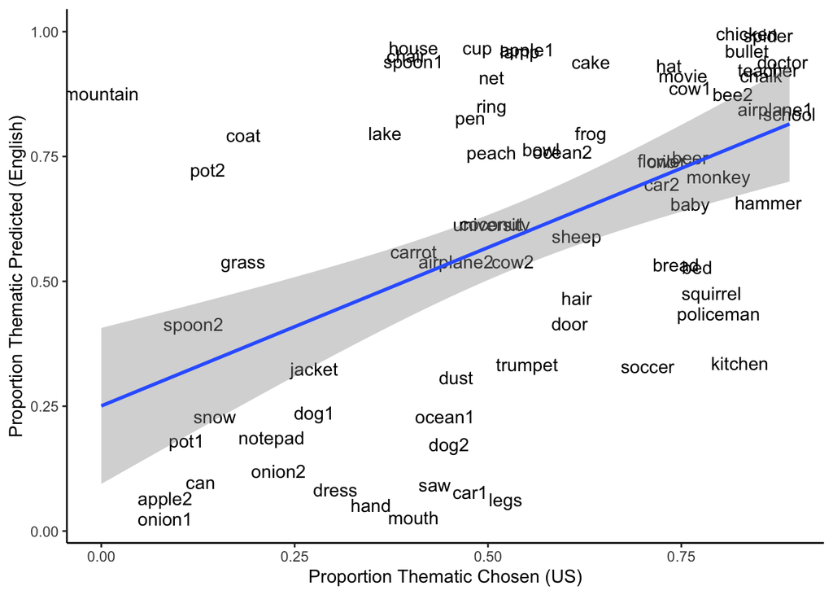

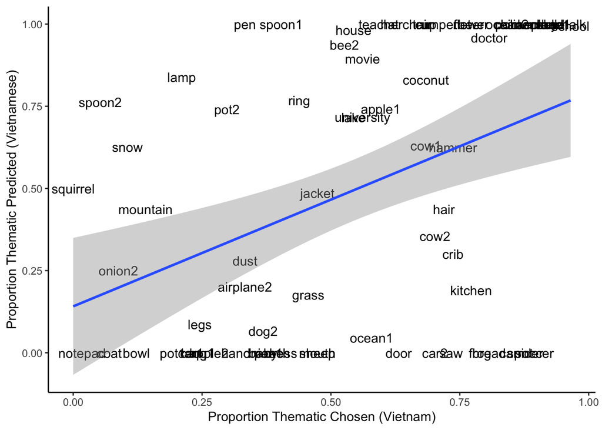

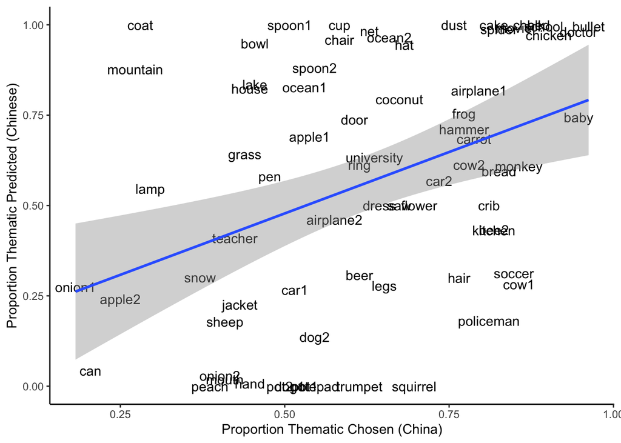

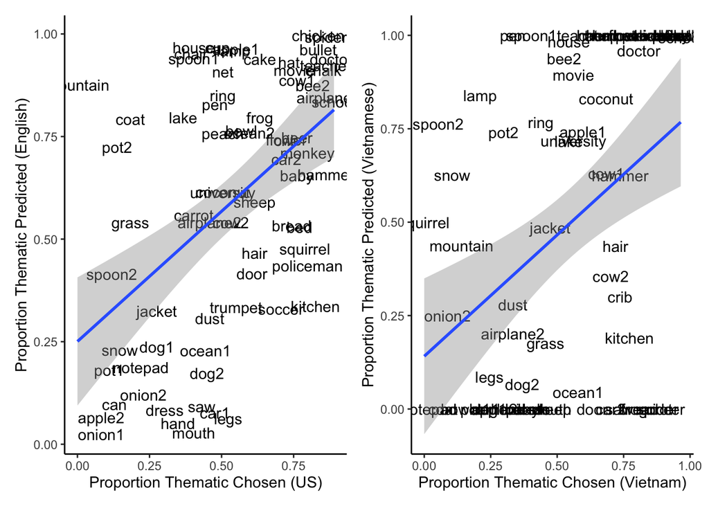

Correlation between English corpus lexical co-occurrence and US responding, and Vietnamese corpus lexical co-occurrence and Vietnam responding.

```r
df.triad_country_freq   #sanity

df.triad_country_freq_E <- df.triad_country_freq %>%
  filter(country == "US")

#plotting English corpus against US responding data
plotE = ggplot(data = df.triad_country_freq_E,
        mapping = aes(x = emp_theme_prop,
                     y = theme_freq_prop_E,
                     label = triad)) +
   geom_text() +
   geom_smooth(method = "lm") +
   labs(x = "Proportion Thematic Chosen (US)",
        y = "Proportion Thematic Predicted (English)")
plotE
df.triad_country_freq_V <- df.triad_country_freq %>%
  filter(country == "Vietnam")

#plotting Vietnamese corpus against VN responding data
plotV = ggplot(data = df.triad_country_freq_V,
        mapping = aes(x = emp_theme_prop,
                     y = theme_freq_prop_V,
                     label = triad)) +
   geom_text() +
   geom_smooth(method = "lm") +
   labs(x = "Proportion Thematic Chosen (Vietnam)",
        y = "Proportion Thematic Predicted (Vietnamese)")
plotV
df.triad_country_freq_M <- df.triad_country_freq %>%
  filter(country == "China")

#plotting China corpus against CN responding data
plotM = ggplot(data = df.triad_country_freq_M,
        mapping = aes(x = emp_theme_prop,
                     y = theme_freq_prop_M,
                     label = triad)) +
   geom_text() +
   geom_smooth(method = "lm") +
   labs(x = "Proportion Thematic Chosen (China)",
        y = "Proportion Thematic Predicted (Chinese)")
plotM
#Pearson correlation between corpus and responding
corr.E = apa_print(cor.test(df.triad_country_freq_E$emp_theme_prop,
                  df.triad_country_freq_E$theme_freq_prop_E, na.rm=T))
corr.E

corr.V = apa_print(cor.test(df.triad_country_freq_V$emp_theme_prop,
                  df.triad_country_freq_V$theme_freq_prop_V, na.rm=T))
corr.V

corr.M = apa_print(cor.test(df.triad_country_freq_M$emp_theme_prop,
                  df.triad_country_freq_M$theme_freq_prop_M, na.rm=T))
corr.M

#Pearson correlation between EN and VI corpus
corr.EV = apa_print(cor.test(df.triad_country_freq_V$theme_freq_prop_V,
                   df.triad_country_freq_E$theme_freq_prop_E, na.rm=T))
```

We first conducted a Pearson correlation test between corresponding response data and corpus data. Looking at the raw lexical co-occurrence data, proportion of US thematic responding is moderately correlated to English corpus thematic proportion, $r = .49$, 95% CI $[.29, .65]$, $t(70) = 4.74$, $p < .001$. Proportion of Vietnam thematic responding is moderately correlated to Vietnamese corpus thematic proportion, $r = .41$, 95% CI $[.20, .59]$, $t(70) = 3.78$, $p < .001$. There was a strong similarity signal between the thematic proportions in the two corpora, $r = .65$, 95% CI $[.49, .77]$, $t(70) = 7.14$, $p < .001$.

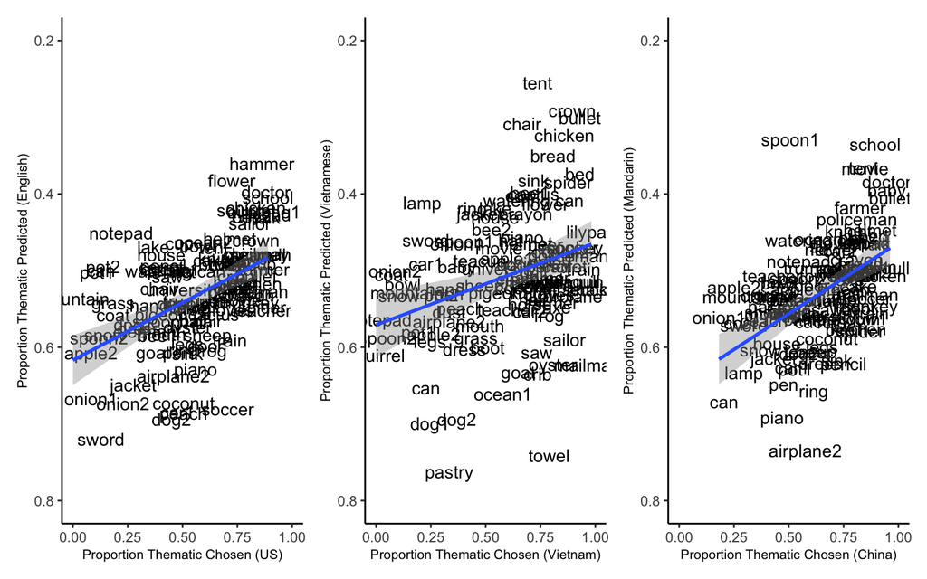

Correlation between English corpus cosine distance and US responding; Vietnamese corpus cosine distance and Vietnam responding; and Mandarin corpus cosine distance and China responding.

Looking at the cosine distance data using fastText word vectors, proportion of US thematic responding is moderately correlated to English thematic cosine distance proportion, $r = -.48$, 95% CI $[-.61, -.32]$, $t(103) = -5.54$, $p < .001$. There is a small correlation between proportion of Vietnam thematic responding and the Vietnamese thematic cosine distance proportion, $r = -.25$, 95% CI $[-.42, -.06]$, $t(103) = -2.60$, $p = .011$. Proportion of China thematic responding is moderately correlated to Mandarin thematic match cosine distance proportion, $r = -.49$, 95% CI $[-.62, -.33]$, $t(103) = -5.71$, $p < .001$. There were moderate signals of similarity between English and Mandarin ($r = .47$, 95% CI $[.31, .61]$, $t(103) = 5.46$, $p < .001$). There was no significant correlation between English and Vietnamese ($r = .08$, 95% CI $[-.11, .27]$, $t(103) = 0.81$, $p = .421$), and between Vietnamese and Mandarin ($r = .15$, 95% CI $[-.04, .33]$, $t(103) = 1.57$, $p = .119$).

To test whether variation in lexical co-occurrence can explain differences in similarity judgments between US and Vietnam participants, we compare logistic mixed-effects regression models fit to the thematic responding data from each country separately. We first ask how well each corpus model (English, Vietnamese, or Mandarin) predicts similarity judgments by speakers of the corresponding language (US, Vietnam, or China). To do this, we use a mixed-effects logistic regression to predict triad responses (0=taxonomic or 1=thematic) with corpus prediction (proportion thematic co-occurrence or cosine distance) as a fixed effect and participant and triad as random effects.

#### Raw lexical co-occurrences

Both the English (EN) and Vietnamese (VI) corpus are significant predictors of US responding (EN-US model: $\beta$ = 2.15, $\chi^2$(1) = 19.86, p < .001; VI-US model: $\beta$ = 1.28, $\chi^2$(1) = 12.05, p < .001).

Similarly, both the English (EN) and Vietnamese (VI) corpus are significant predictors of Vietnam (VN) responding (EN-VN model: $\beta$ = 2.11, $\chi^2$(1) = 14.18, p < .001; VI-VN model: $\beta$ = 1.52, $\chi^2$(1) = 13.82, p < .001).

This suggests a strong shared similarity signal across the languages, which is also reflected in the strong correlation between the two corpus models reported above ($r = .65$, 95% CI $[.49, .77]$, $t(70) = 7.14$, $p < .001$).

#### Cosine distances of fastText word vectors

Similar to the results from the analysis with raw lexical co-occurrences, we found that all corpora are significant predictors of all cultural context responding.

For US responding: English (EN), Vietnamese (VI), and Mandarin (ZH) corpus are significant predictors of US responding (EN-US model: $\beta$ = -9.05, $\chi^2$(1) = 31.28, p < .001; VI-US model: $\beta$ = -3.13, $\chi^2$(1) = 5.1, p = 0.024; ZH-US model: $\beta$ = -7.42, $\chi^2$(1) = 18.48, p < .001).

For Vietnam (VN) responding: English (EN), Vietnamese (VI), and Mandarin (ZH) corpus are significant predictors of VN responding (EN-VN model: $\beta$ = -6.86, $\chi^2$(1) = 11.71, p < .001; VI-VN model: $\beta$ = -3.83, $\chi^2$(1) = 6.02, p = 0.014; ZH-VN model: $\beta$ = -7.49, $\chi^2$(1) = 13.84, p < .001).

### Is responding in each cultural context **best** predicted by the corresponding corpus’s lexical statistics (raw co-occurrences and cosine distance), as opposed to the other two corpora?

Next, we directly compare the corpus models by including both as fixed effects in two mixed-effect regressions (predicting US and Vietnam responding) with the same random effects as above. In R syntax, the model is: response ~ corpus_English + corpus_Vietnamese + corpus_Mandarin + (1|triad) + (1|subject).

#### Raw co-occurrences

When we included both corpora as predictors for US responding, only the English corpus has a significant effect ($\beta$ = 1.57, $\chi^2$(1) = 12.12, p < .001). There is no effect of the Vietnamese corpus ($\beta$ = 0.62, $\chi^2$(1) = 2.56, p = 0.11).

However, when both corpora are included as predictors for Vietnam responding – both corpora has a significant effect (English corpus: $\beta$ = 1.6, $\chi^2$(1) = 9.68, p = 0.002; Vietnamese corpus: $\beta$ = 0.89, $\chi^2$(1) = 3.99, p = 0.046).

#### Cosine distances of fastText word vectors

For Vietnam responding: English (EN), Vietnamese (VI), and Mandarin (ZH) corpus are all significant predictors. EN corpus: $\beta$ = -4.25, $\chi^2$(1) = 3.87, p = 0.049. VI corpus: $\beta$ = -2.98, $\chi^2$(1) = 4.17, p = 0.041. ZH corpus: $\beta$ = -4.86, $\chi^2$(1) = 4.94, p = 0.026.

We observed some level of language specificity from this analysis. The English corpus is the best predictor for US responding, and the Mandarin corpus is the best predictor for China response. While this is not the case with the Vietnamese corpus and the Vietnam responding, the Vietnamese corpus is still a significant predictor for the Vietnam responding.

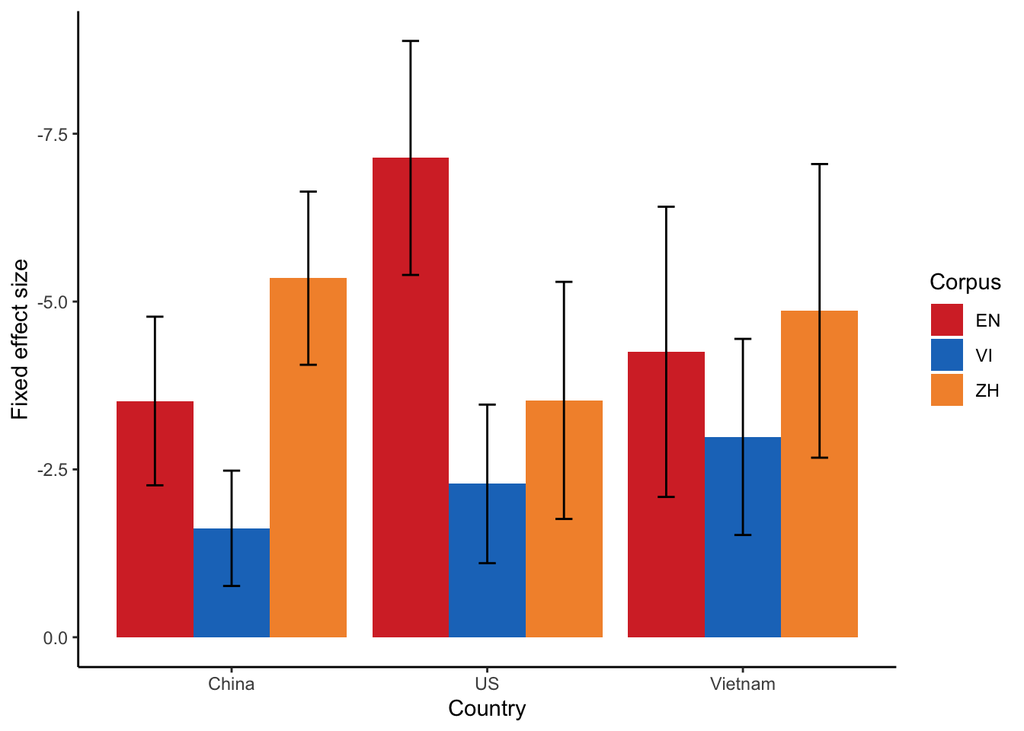

Fixed effect sizes of each corpus when included as a predictor for China, US, and Vietnam responding, respectively. The English corpus is the best predictor for US response, and the Mandarin corpus is the best predictor for China response.

However, we found that language specificity alone does not explain our results. We used an ANOVA to compare the model with only the corresponding corpus, and the model with all 3 corpora for each cultural context. We found that in all three cases (US, China, Vietnam), adding the other two corpora produces a significantly better fit than the identical model without the additional corpora, and only the corresponding corpus included as a predictor (US response: $\chi^2$(2) = 8.42, p = 0.015; Vietnam response: $\chi^2$(2) = 15.21, p = < .001; China response: $\chi^2$(2) = 10.83, p = 0.004).

We carried out an ANOVA model comparison to compare our approach with previous studies that did not include corpus information. Because @Ji2004 only compared US and China participants, we filtered our data to only include responding data from these two countries. Our approach would be to compare a model that only includes country (US or China) as a fixed effect with one that also includes English and Chinese corpus data. Our previous model with an intercept per subject and one per triad, as well as by-triad random slopes for country to account for variation in the country effect across triads fails to converge with the more complex model, so we include a simpler random effect structure with an intercept per subject and one per triad in both the basic and more complex model. We compare this model with an identical model but including Chinese and English corpus cosine distance proportion prediction. We found that adding English and Chinese corpus data produces a significantly better fit than the identical model without English and Chinese corpus data as predictors ($\chi^2$(2) = 43.03, p = < .001. This suggests that including corpus data would better model the cross-cultural differences in similarity judgment in this study as well as similar studies.

## Exploratory analysis

Because our exclusion criterion for attention checks excluded over 50% Vietnam participants, we carried out exploratory analysis where we applied less stringent exclusion criteria. In the following analysis, we only exclude participants who miss more than 2 attention checks (rather than any attention checks). We kept the rest of the exclusion criteria.

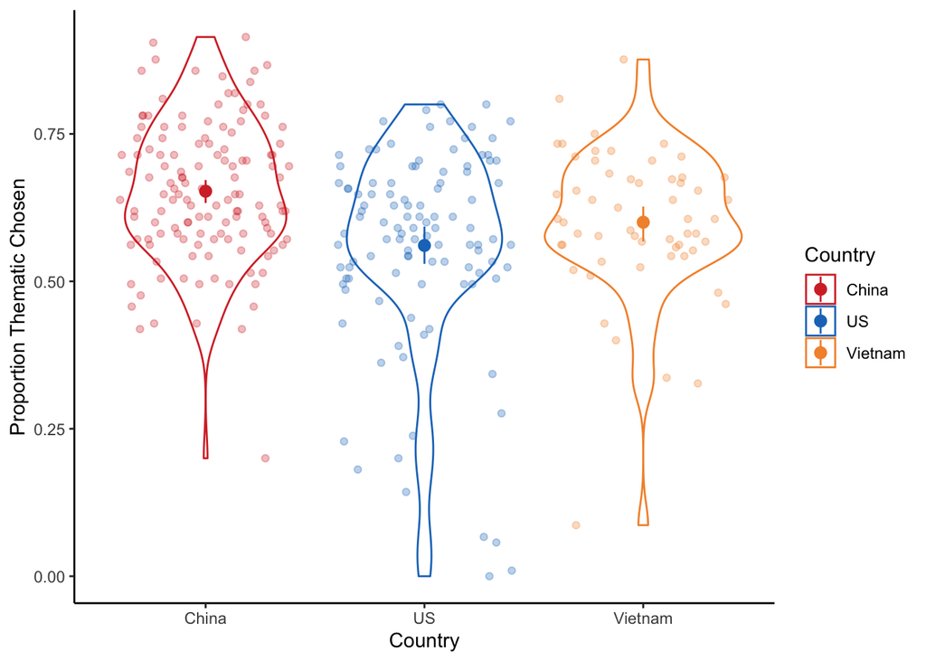

Proportion of thematic responses by country, with a less stringent attention check criterion. We did not find any significant differences from the analysis reported above with a more stringent criterion.

There is no significant difference in this round of analysis compared to the one reported above (with more stringent attention check criterion). That is, we still observed a significant effect of country on proportion of thematic responses ($\chi^2$(2) = 15.22, p < .001), but this effect is driven by only the difference between US and China response ($\beta$ = -0.53, p < .001). There is no statistical difference between the Vietnam and China response ($\beta$ = -0.25, p = 0.137), and the US and Vietnam response ($\beta$ = 0.28, p = 0.137).

# Discussion

In this paper, we consider whether statistics of the language environment can account for cross-cultural differences in a classic similarity judgment paradigm, as an alternative to the view that members of different cultures vary in their conception of similarity.

There are some suggestions that the current approach can predict triad-specific cross-cultural effects. First of all, an ANOVA model comparison showed that adding a random effect term for varying slope by country and varying intercept by triad to the model produces a significant better fit than the identical model without this random effect term included as a predictor ($\chi^2$(6) = 6210.88, p < .001)

Anecdotally, we show below some examples of triads that show contrasting difference in the magnitude of difference in thematic responses between countries. As a review, the overall result across all triads showed that there was significant difference between US and China responding, and no significant differences between US and Vietnam or China and Vietnam responding. However, we observed that for the triad “cow-grass-chicken,” there were significant differences between US and China, and US and Vietnam responding. There was no significant difference between China and Vietnam responding. For the triad “spoon-sugar-fork,” there were significant difference between China and US, and China and Vietnam responding, but no significant difference between US and Vietnam. For the triad “hair-comb-beard,” there were no significant differences pairwise across the three cultural contexts. This suggests that there are triad-specific cross-cultural effects in play. Beyond emphasizing the importance of including triad predictors as a random effect, this finding suggests that, firstly, future similar studies need to report triads that are used, as the triads used can affect results (for example, if a study only includes triads where China and US responding are significantly different, it would be more likely to conclude that Chinese and US cultures hold different notions of similarity). Secondly, that future studies can look more deeply into which groups of triads are driving the US-China responding difference. For example, triads belonging to different semantic neighborhoods might be influencing cross-cultural responding in different ways.

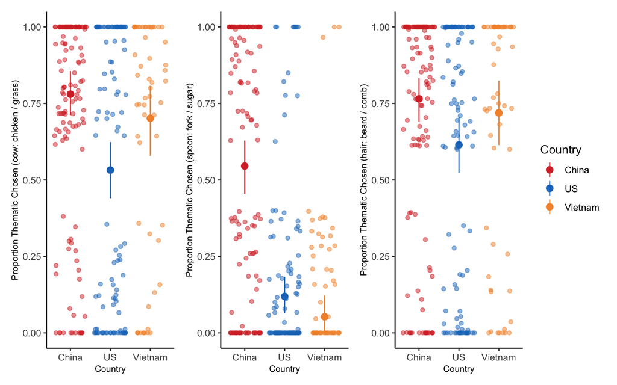

We also identified some data quality / quantity issues that are an obstacle to modeling similarity in Vietnamese and Mandarin. As stated above, we were not able to find a Mandarin corpus with raw co-occurrences that contains similar magnitude of number of sentences as our English corpus (COCA). Additionally, we could only retrieve fastText word vectors for Vietnamese and Mandarin that are trained on both Common Crawl and Wikipedia. 63% of the articles on Vietnamese Wikipedia and 16% of the Chinese Wikipedia are bot translations from another language (compared to 3% of English Wikipedia). This would affect the quality of the word vectors trained on the Vietnamese and Chinese Wikipedia, potentially making them not reflecting the naturally-occurring lexical co-occurrence in the corresponding language.

Our findings raise additional questions for future work: if not differences in taxonomic vs. thematic responding, then what differences drive the relativity effects previous studies have observed? To what extent are the relativity effects driven by language, and to what extent by culture? @Ji2004 established that culture-aligned differences in this paradigm exist, even when the test language is held constant, concluding that “it is culture (independent of the testing language) that led to different grouping styles” in their study. Our data provide a cautionary note to this conclusion, suggesting that semantic representations in bilinguals (see @Francis2005 for a review) may have the potential to provide an offline account for cross-context differences in similarity judgments, independent of test language. However, there are still many open questions for this account. How do semantic associations guide categorization? Can they explain taxonomic-thematic differences of the type reported by @Ji2004 and others? Can we provide a more specific computational account than the simple frequency model tested here?

Despite these caveats, our findings here demonstrate the plausibility of an alternative perspective on cross-cultural accounts of language, thought, and similarity in the case of taxonomic and thematic reasoning: that it may be the input to similarity judgments, rather than the evaluative process or the conceptualization of similarity that produces variation in similarity reasoning across cultural and linguistic contexts. We hope this work provides a foundation for further research probing this question.